# Assessment 1 Part 3

Andrea Botes

20.05.2022`

# Part 2: Analysis & Visualisation

## Data import

```r
table1<- read_csv("digitalmarketing_short_07_05_22.csv")
table2<- read_csv("digitalmarketing_short_14_05_22.csv")
table3<- read_csv("digitalmarketing_short_15_05_22.csv")
one <- table1
two <- table2
three <- table3

digitalmarketing_combine <- bind_rows(one, two, three, id = NULL)
```

Cleaner version:

```r
#look at first 10 obs
digitalmarketing_combine%>%
  head(10)
```

```
## # A tibble: 10 × 10
##    user_id screen_name  created_at          text    favorite_count retweet_count
##      <dbl> <chr>        <dttm>              <chr>            <dbl>         <dbl>
##  1 9.51e17 weblinkspark 2022-05-07 07:38:01 "Why W…              0             0
##  2 9.51e17 weblinkspark 2022-05-04 07:08:13 "Why W…              1             0
##  3 9.51e17 weblinkspark 2022-05-06 06:08:26 "8 Rea…              0             0
##  4 9.51e17 weblinkspark 2022-05-02 08:18:12 "Socia…              0             0
##  5 9.51e17 weblinkspark 2022-05-03 06:27:19 "Micro…              0             0
##  6 9.51e17 weblinkspark 2022-05-05 13:42:52 "Here …              2             0
##  7 9.51e17 weblinkspark 2022-05-05 06:22:25 "12 Es…              0             0
##  8 9.51e17 weblinkspark 2022-05-03 06:02:23 "Googl…              0             0
##  9 9.51e17 weblinkspark 2022-05-05 14:34:51 "40 Be…              2             0
## 10 9.51e17 weblinkspark 2022-05-03 15:07:59 "Top a…              1             3
## # … with 4 more variables: urls_expanded_url <lgl>, hashtags <lgl>,
## #   mentions_screen_name <lgl>, location <chr>
```

```r
#look at structure
digitalmarketing_combine%>%
  str()
```

```
## spec_tbl_df [53,091 × 10] (S3: spec_tbl_df/tbl_df/tbl/data.frame)
##  $ user_id             : num [1:53091] 9.51e+17 9.51e+17 9.51e+17 9.51e+17 9.51e+17 ...
##  $ screen_name         : chr [1:53091] "weblinkspark" "weblinkspark" "weblinkspark" "weblinkspark" ...
##  $ created_at          : POSIXct[1:53091], format: "2022-05-07 07:38:01" "2022-05-04 07:08:13" ...
##  $ text                : chr [1:53091] "Why Website Speed Should be an Optimization Priority? https://t.co/nCRZO9a2tD #SEO #DigitalMarketing #WebsiteSpeed #UX" "Why Website Speed Should be an Optimization Priority? https://t.co/nCRZO9a2tD #SEO #DigitalMarketing #WebsiteSp"| __truncated__ "8 Reaso…
##  $ favorite_count      : num [1:53091] 0 1 0 0 0 2 0 0 2 1 ...
##  $ retweet_count       : num [1:53091] 0 0 0 0 0 0 0 0 0 3 ...
##  $ urls_expanded_url   : logi [1:53091] NA NA NA NA NA NA ...
##  $ hashtags            : logi [1:53091] NA NA NA NA NA NA ...
##  $ mentions_screen_name: logi [1:53091] NA NA NA NA NA NA ...
##  $ location            : chr [1:53091] "Indore, India" "Indore, India" "Indore, India" "Indore, India" ...
##  - attr(*, "spec")=
##   .. cols(
##   ..   user_id = col_double(),
##   ..   screen_name = col_character(),
##   ..   created_at = col_datetime(format = ""),
##   ..   text = col_character(),
##   ..   favorite_count = col_double(),
##   ..   retweet_count = col_double(),
##   ..   urls_expanded_url = col_logical(),
##   ..   hashtags = col_logical(),
##   ..   mentions_screen_name = col_logical(),
##   ..   location = col_character()
##   .. )
##  - attr(*, "problems")=<externalptr>
```

```r
digitalmarketing_combine_short<-digitalmarketing_combine %>%
  select(user_id , screen_name , created_at , text , favorite_count, retweet_count, urls_expanded_url, hashtags, mentions_screen_name, location)

digitalmarketing_combine_short%>%write_csv("final_digitalmarketing_combine_short_20_05_22.csv")
digitalmarketing_combine<-read_csv("final_digitalmarketing_combine_short_20_05_22.csv")
```

### Explore frequency of tweets

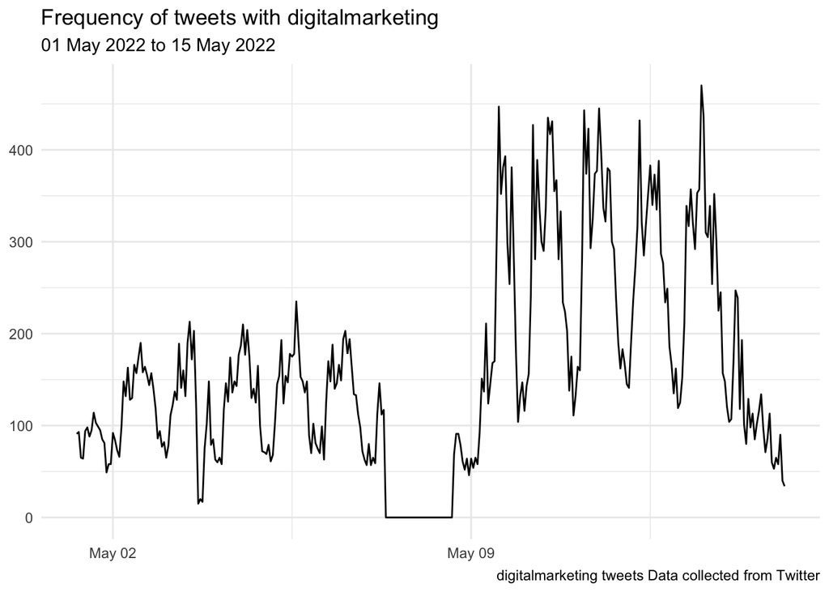

```r
ts_plot(digitalmarketing_combine, "hours") +
  labs(x = NULL, y = NULL,
       title = "Frequency of tweets with digitalmarketing",
       subtitle = paste0(format(min(digitalmarketing_combine$created_at), "%d %B %Y"), " to ", format(max(digitalmarketing_combine$created_at),"%d %B %Y")),
       caption = "digitalmarketing tweets Data collected from Twitter") +
  theme_minimal()
```

### Top tweeting location

```r
digitalmarketing_combine_short %>%
  filter(!is.na(location)) %>%
  count(location, sort = TRUE) %>%
  top_n(10)
```

```
## # A tibble: 10 × 2
##    location                     n
##    <chr>                    <int>
##  1 India                     1568
##  2 New Delhi, India          1135
##  3 Worldwide                 1113
##  4 United States             1033
##  5 London, England            927
##  6 Dallas, TX                 847
##  7 Henderson, NV, US, 89009   813
##  8 Global                     745
##  9 Dhaka, Bangladesh          650
## 10 Manchester,England         641
```

### Most frequently shared link

```r
digitalmarketing_combine_short %>%
  filter(!is.na(urls_expanded_url)) %>%
  count(urls_expanded_url, sort = TRUE) %>%
  top_n(5)
```

```
## # A tibble: 0 × 2
## # … with 2 variables: urls_expanded_url <lgl>, n <int>
```

```r
digitalmarketing_combine %>%
  arrange(-retweet_count) %>%
  slice(20) %>%
  select(created_at, screen_name, text, retweet_count)
```

```
## # A tibble: 1 × 4
##   created_at          screen_name text                             retweet_count
##   <dttm>              <chr>       <chr>                                    <dbl>
## 1 2022-05-13 15:25:16 aboutlilien The beautiful and kind-hearted …            37
```

## Embed tweets in the RMarkdown

`gadenbuie/tweetrmd: Embed Tweets in R Markdown` Easily embed Tweets anywhere R Markdown turns plain text into HTML.

https://github.com/gadenbuie/tweetrmd

[figure not shown]

```r
#devtools::install_github("gadenbuie/tweetrmd")
#devtools::install_github('rstudio/webshot2')


library(tweetrmd)
library(webshot2)
tweet_screenshot(tweet_url("Tanjilasmm", "1523884824758751232"))
```

### Most liked tweet

```r
digitalmarketing_combine %>%
  arrange(-favorite_count) %>%
  top_n(15, favorite_count) %>%
  select(created_at, screen_name, text, favorite_count)
```

```
## # A tibble: 15 × 4
##    created_at          screen_name     text                       favorite_count
##    <dttm>              <chr>           <chr>                               <dbl>
##  1 2022-05-11 04:02:58 ca_lightray     "✅Here is an excellent a…            650
##  2 2022-05-11 04:02:58 ca_lightray     "✅Here is an excellent a…            649
##  3 2022-05-11 23:50:32 ca_lightray     "We met Sharon @SDGConsul…            588
##  4 2022-05-11 23:50:32 ca_lightray     "We met Sharon @SDGConsul…            587
##  5 2022-05-02 16:57:33 Google          "Learn the latest in digi…            486
##  6 2022-05-11 22:25:49 MrThunderCrypto "To help with this red re…            138
##  7 2022-05-11 22:25:49 MrThunderCrypto "To help with this red re…            137
##  8 2022-05-13 16:29:16 mmgbenusola     "Do NFT you say No\n\nDo …            117
##  9 2022-05-11 09:03:20 HostIndotPk     "Unlimited cPanel Hosting…            117
## 10 2022-05-13 16:29:16 mmgbenusola     "Do NFT you say No\n\nDo …            115
## 11 2022-05-03 13:13:47 Kaltura         "Wait, don't go! With Kal…            113
## 12 2022-05-04 06:59:51 ChertonM        "Your talent and our prom…            112
## 13 2022-05-13 20:00:09 AlexVerdea      "Another big thanks to @A…            112
## 14 2022-05-02 08:22:03 ChertonM        "PR Marketing is a host o…            105
## 15 2022-05-06 05:45:59 ONPASSIVE       "Reach a wider audience a…             97
```

### Top tweeters

To identify the most active tweeters we can use the “screen_name” variable to tot up the number of tweets by Twitter handle. We can then add back the @ symbol using the paste0() function.

```r
digitalmarketing_combine %>%
  count(screen_name, sort = TRUE) %>%
  top_n(5) %>%
  mutate(screen_name = paste0("@", screen_name))
```

```
## # A tibble: 5 × 2
##   screen_name         n
##   <chr>           <int>
## 1 @adsthumb         888
## 2 @DmarketingwebD   813
## 3 @pallavkaushish   786
## 4 @marcflood        767
## 5 @JobPreference    752
```

## Top emoji

To identify the most frequently used emoji we can use the `ji_extract_all()` function from the `emo` package.

This function extracts all the emojis from the text of each tweet.

We can then use the unnest() function from the tidyr package to split out the emojis, count, sort in descending order and identify the top 10.

```r
#devtools::install_github("hadley/emo")
library(emo)
digitalmarketing_combine %>%
  mutate(emoji = ji_extract_all(text)) %>%
  unnest(cols = c(emoji)) %>%
  count(emoji, sort = TRUE) %>%
  top_n(10)
```

```
## # A tibble: 10 × 2
##    emoji     n
##    <chr> <int>
##  1 👇     1542
##  2 👉     1342
##  3 🌐      555
##  4 ✅      516
##  5 🔥      312
##  6 📞      297
##  7 💻      282
##  8 🚀      270
##  9 🥭      257
## 10 ✨      246
```

### Top hashtags

To pull out the hashtags from the text of each tweet we first need to convert the text into a one word per row format using the `unnest_tokens()` function from the `tidytext` package. We then select only those terms that have a hashtag, count them, sort in descending order and pick the top 10.

```r
library(tidytext)
digitalmarketing_combine %>%
  unnest_tokens(hashtag, text, "tweets", to_lower = FALSE) %>%
  filter(str_detect(hashtag, "^#"),
        hashtag != "#traditionalmarketing") %>%
  count(hashtag, sort = TRUE) %>%
  top_n(10)
```

```
## # A tibble: 10 × 2
##    hashtag                   n
##    <chr>                 <int>
##  1 #digitalmarketing     29650
##  2 #DigitalMarketing     22148
##  3 #marketing            11888
##  4 #business              6221
##  5 #socialmedia           5643
##  6 #SEO                   5492
##  7 #seo                   5133
##  8 #socialmediamarketing  4899
##  9 #Marketing             4108
## 10 #branding              3529
```

### Top mentions

Here we tokenise the text of each tweet and use `str_detect()` from the `tidyverse` package to filter out words that start with an @ .

```r
digitalmarketing_combine %>%
  unnest_tokens(mentions, text, "tweets", to_lower = FALSE) %>%
  filter(str_detect(mentions, "^@")) %>%
  count(mentions, sort = TRUE) %>%
  top_n(10)
```

```
## # A tibble: 10 × 2
##    mentions           n
##    <chr>          <int>
##  1 @sejournal       807
##  2 @Charlesfrize    634
##  3 @DLAIgnite       237
##  4 @digiday         235
##  5 @Ondeckeo        235
##  6 @TimothyHughes   166
##  7 @martinibuster   143
##  8 @sengineland     139
##  9 @Google          138
## 10 @opensea         128
```

# Part 3: Topic Modeling & visualisation

## Preprocess text from dataset to tidy text & convert to DocumenttermMatric

### Clean up dataset text

```r
tidy_digitalmarketing <- digitalmarketing_combine %>%
  mutate(text) %>%
  unnest_tokens(word , text) %>%
  anti_join(get_stopwords()) %>%
  filter(!is.na(word) & !grepl("[^A-Za-z]" , word) & word != "https" & word !="na")
tidy_digitalmarketing %>%
  count(word , sort = TRUE)
```

```
## # A tibble: 43,671 × 2
##    word                     n
##    <chr>                <int>
##  1 digitalmarketing     53549
##  2 marketing            28264
##  3 seo                  14389
##  4 business             13679
##  5 digital              10301
##  6 socialmedia           7364
##  7 socialmediamarketing  6284
##  8 website               5652
##  9 contentmarketing      4619
## 10 via                   4398
## # … with 43,661 more rows
```

### Convert to DocumentTermMatrix

```r
digitalmarketing_corpus <- Corpus(VectorSource(digitalmarketing_combine))
digitalmarketing_dtm <- DocumentTermMatrix(digitalmarketing_corpus)
digitalmarketing_dtm
```

```
## <<DocumentTermMatrix (documents: 10, terms: 182453)>>
## Non-/sparse entries: 183049/1641481
## Sparsity           : 90%
## Maximal term length: 277
## Weighting          : term frequency (tf)
```

### Use ‘LDA()’ function to create LDA model

```r
#set a seed so that the output of the model is predictable

digitalmarketing_lda <-  LDA(digitalmarketing_dtm , k=5 , control = list(seed = 1234))
digitalmarketing_lda
```

```
## A LDA_VEM topic model with 5 topics.
```

```r
dm_topics <- tidy(digitalmarketing_lda , matrix = "beta")
```

### Visualise the top 10 words from each topic to brainstorm possible topics that they may cover

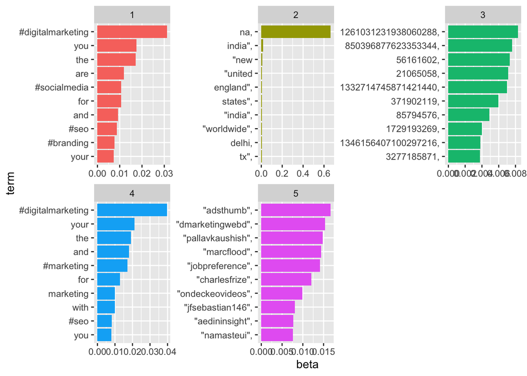

```r
# install.packages("reshape2")

library(ggplot2)
library(dplyr)

dm_top_terms <- dm_topics %>%
  group_by(topic) %>%
  slice_max(beta, n = 10) %>%
  ungroup() %>%
  arrange(topic, -beta)

dm_top_terms %>%
  mutate(term = reorder_within(term, beta, topic)) %>%
  ggplot(aes(beta, term, fill = factor(topic))) +
  geom_col(show.legend = FALSE) +
  facet_wrap(~topic, scales = "free") +
  scale_y_reordered()
```

```r
beta_wide <- dm_topics %>%
  mutate(topic=paste0("topic", topic)) %>%
  pivot_wider(names_from = topic, values_from = beta) %>%
  filter(topic1> .001 | topic2> .001) %>%
  mutate(log_ratio = log2(topic2/topic1))
```

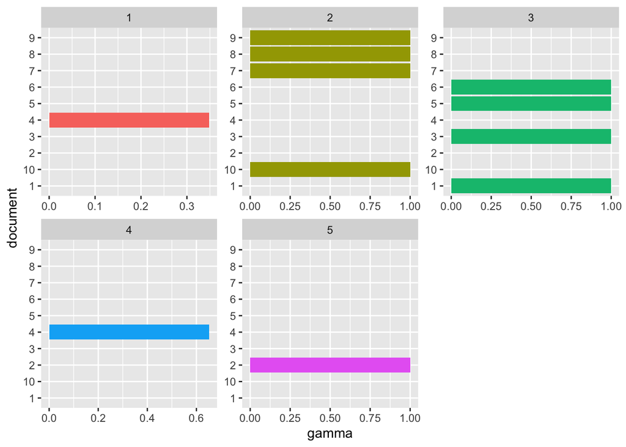

```r
dm_topics <- tidy(digitalmarketing_lda , matrix = "gamma")

dm_top_terms <- dm_topics %>%
  group_by(topic) %>%
  slice_max(gamma, n = 10) %>%
  ungroup() %>%
  arrange(topic, -gamma)

dm_top_terms %>%
  mutate(term = reorder_within(document, gamma, topic)) %>%
  ggplot(aes(gamma, document, fill = factor(topic))) +
  geom_col(show.legend = FALSE) +
  facet_wrap(~topic, scales = "free") +
  scale_y_reordered()
```

```r
gamma_wide <- dm_topics %>%
  mutate(topic=paste0("topic", topic)) %>%
  pivot_wider(names_from = topic, values_from = gamma) %>%
  filter(topic1> .001 | topic2> .001) %>%
  mutate(log_ratio = log2(topic2/topic1))
```